# Factors Correlated With State Reopening Rates

Marshall Bushman, Mingze Gao, Alec Gossai, Hanna Yu

4/15/2021

# Introduction

In this project, we examine factors correlated with state’s levels of COVID-19 pandemic reopening in the United States. We consider the percentage of fully vaccinated people in each state, the share of essential industries in each state, and the political affiliation of state governors.

Methodology  
All the data are taken between April 7 and April 10th, 2021. We use a multiple regression best linear predictor model.

```r
library("foreign")    # to import stata data files
library("AER")        # contains ivreg command
```

# Data

Our variables of interest are:  
* `Score`: COVID-19 State Reopening Score  
* `Percent_vaccinated`: Percent of population fully vaccinated  
* `Percent_ess`: Share of essential industries that are not health care nor front line  
* `Gov_party`: Party affiliation of the state governors

These are collected from the following sources:

COVID-19 State Reopening Guide  
https://www.multistate.us/issues/covid-19-state-reopening-guide  
CDC COVID Data Tracker  
https://covid.cdc.gov/covid-data-tracker/#vaccinations  
Share of private employment in pandemic-essential industries  
https://www.bls.gov/opub/ted/2021/107-5-million-private-sector-workers-in-pandemic-essential-industries-in-2019.htm  
State party control, contains both legislature and governor parties  
https://www.kff.org/other/state-indicator/state-political-parties/?currentTimeframe=0&selectedDistributions=governor-political-affiliation--state-senate-majority-political-affiliation--state-house-majority-political-affiliation--state-attorney-general-political-affiliation--state-insurance-commissioner-political-affiliation&sortModel=%7B%22colId%22:%22Location%22,%22sort%22:%22asc%22%7D

State reopening scores are calculated by the consulting firm MultiState. States were evaluated based on eleven factors including whether or not a stay-at-home order is in place, whether businesses are reopened and limits on the size of in-person gatherings.

Essential industries, also called “pandemic-essential” industries, are determined based on the CDC’s recommended vaccination phases. We use industries in the “Phase 1C” category, which are “other essential industries” not including essential health care industries and front line essential industries.

## Preliminary data analysis

Load our datasets

```r
reopening_data <- read.csv("reopening_data.csv") # 4/7/21
# daily_travel <- read.csv("Trips_by_Distance.csv") # 4/5/21
cdc_vaccine <- read.csv("covid19_vaccinations_in_the_united_states.csv") # 4/10/21
party <- read.csv("state_political_parties.csv") # 2021
essential <- read.csv("essential industries.csv")

# Cleaning
colnames(reopening_data)[1] <- "State"
colnames(cdc_vaccine)[1] <- "State"
cdc_vaccine[cdc_vaccine$State=="New York State","State"] <- "New York";
colnames(party)[1] <- "State"
```

Extract the information we want into `df`.

```r
reopening_data <- reopening_data[order(reopening_data$State),]
df <- data.frame(State = reopening_data$State, Score = reopening_data$Score)
vaccine_states <- subset(cdc_vaccine,
                         State %in% c("Alabama", "Alaska", "Arizona", "Arkansas",
                                      "California", "Colorado", "Connecticut", "Delaware",
                                      "Florida", "Georgia", "Hawaii", "Idaho", "Illinois",
                                      "Indiana", "Iowa", "Kansas", "Kentucky",
                                      "Louisiana", "Maine", "Maryland", "Massachusetts",
                                      "Michigan", "Minnesota", "Mississippi", "Missouri",
                                      "Montana", "Nebraska", "Nevada", "New Hampshire",
                                      "New Jersey", "New Mexico", "New York",
                                      "North Carolina", "North Dakota", "Ohio",
                                      "Oklahoma", "Oregon", "Pennsylvania",
                                      "Rhode Island", "South Carolina", "South Dakota",
                                      "Tennessee", "Texas", "Utah", "Vermont", "Virginia",
                                      "Washington", "West Virginia", "Wisconsin",
                                      "Wyoming"))
vaccine_states <- vaccine_states[order(vaccine_states$State),]
df$Percent_vaccinated <-
  vaccine_states$Percent.of.Total.Pop.Fully.Vaccinated.by.State.of.Residence
df <- cbind(State_abbrev =
              c("AL", "AK", "AZ", "AR", "CA", "CO", "CT", "DE", "FL", "GA", "HI", "ID",
                "IL", "IN", "IA", "KS", "KY", "LA", "ME", "MD", "MA", "MI", "MN", "MS",
                "MO", "MT", "NE", "NV", "NH", "NJ", "NM", "NY", "NC", "ND", "OH", "OK",
                "OR", "PA", "RI", "SC", "SD", "TN", "TX", "UT", "VT", "VA", "WA", "WV",
                "WI", "WY"), df)

party_states <- subset(party, State != "United States" &
                         State != "District of Columbia")
df$Gov_party = as.factor(party_states$Governor.Political.Affiliation)

essential_states <- subset(essential, State != "U.S. total[1]" &
                           State != "District of Columbia" &
                           State != "Puerto Rico" &
                           State != "U.S. Virgin Islands")
# colnames(essential_states) <- essential_states[1,]
# colnames(essential_states)[1] <- "States"
essential_states <- essential_states[-c(1),]
df$Percent_ess = essential_states$X.2
```

We create plots.

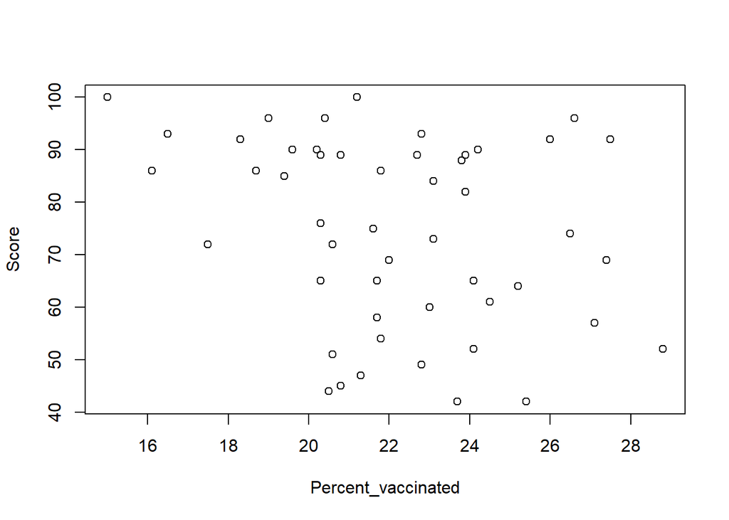

```r
# Score vs Percent_vaccinated
plot(Score ~ Percent_vaccinated, data = df)
```

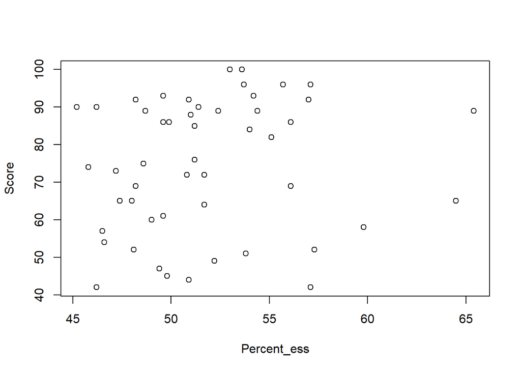

```r
df <- transform(df, Percent_vaccinated = as.numeric(Percent_vaccinated))

# Score vs Percent_ess
df <- transform(df, Percent_ess = as.numeric(Percent_ess)) #typeof(df$Percent_ess[1])
plot(Score ~ Percent_ess, data = df)
```

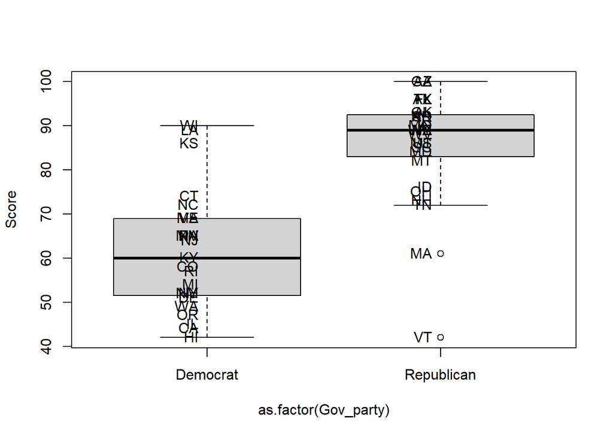

```r
# Score vs. Gov_party
plot(Score ~ as.factor(Gov_party), data = df)
text(Score ~ as.factor(Gov_party), data = df, labels = State_abbrev, pos = 2)
```

# Methodology

We estimate the effect of each factor using the following model:

$$Score = \gamma_0 + \gamma_1Gov\_party + \gamma_2Percent\_vaccinated + \gamma_3Percent\_ess$$
We estimate these parameters by performing multiple linear regression. We use the BLP model instead of the causal model because we believe Assumption 1 does not hold here. For example, we expect the party affiliation of state legislatures to be an ommitted variable that (1) is correlated with the party of state governor, and (2) has a causal effect on the reopening score. Finally, we expect that Assumptions 2 (all our regressors are IID), 3 (large outliers are unlikely), and 4 (no perfect multicollinearity exists) hold.

# Estimation and inference

We estimate the multiple linear regression.

```r
fm <- lm(Score ~ as.factor(Gov_party) + Percent_ess + Percent_vaccinated, data = df)
coeftest(fm, vcov = vcovHC(fm, type = "HC1"), df = Inf)
```

```
##
## z test of coefficients:
##
##                                Estimate Std. Error z value  Pr(>|z|)
## (Intercept)                    57.93941   22.19009  2.6110  0.009026 **
## as.factor(Gov_party)Republican 22.65907    4.38724  5.1648 2.407e-07 ***
## Percent_ess                     0.31635    0.38296  0.8261  0.408767
## Percent_vaccinated             -0.54364    0.63677 -0.8537  0.393246
## ---
## Signif. codes:  0 '***' 0.001 '**' 0.01 '*' 0.05 '.' 0.1 ' ' 1
```

The positive correlation between our reopening score and state governor party affiliation is consistent with recent news that conservative states desire to reopen faster.

We perform a Wald Test to test the overall significance of our model.

```r
fm2 <- lm(Score ~ 1, data = df)
waldtest(fm2, fm, test = "Chisq", vcov = vcovHC(fm, type = "HC1"))
```

```
## Wald test
##
## Model 1: Score ~ 1
## Model 2: Score ~ as.factor(Gov_party) + Percent_ess + Percent_vaccinated
##   Res.Df Df  Chisq Pr(>Chisq)
## 1     49
## 2     46  3 50.285  6.948e-11 ***
## ---
## Signif. codes:  0 '***' 0.001 '**' 0.01 '*' 0.05 '.' 0.1 ' ' 1
```

The Wald test shows that our overall model is significant at the 10% level with P-Value 6.948e-11.

We are perform individual t-tests on all three of our regressors.

```r
# Percent vaccinted
fm <- lm(Score ~ Percent_vaccinated, data = df)
coeftest(fm, vcov = vcovHC(fm, type = "HC1"), df = Inf)
##
## z test of coefficients:
##
##                     Estimate Std. Error z value  Pr(>|z|)
## (Intercept)        110.88350   15.61653  7.1004 1.244e-12 ***
## Percent_vaccinated  -1.64066    0.71657 -2.2896   0.02204 *
## ---
## Signif. codes:  0 '***' 0.001 '**' 0.01 '*' 0.05 '.' 0.1 ' ' 1

# Essential industries
fm <- lm(Score ~ Percent_ess, data = df)
coeftest(fm, vcov = vcovHC(fm, type = "HC1"), df = Inf)
##
## z test of coefficients:
##
##             Estimate Std. Error z value Pr(>|z|)
## (Intercept) 46.05739   28.15195  1.6360   0.1018
## Percent_ess  0.54924    0.54485  1.0081   0.3134

# Political party
fm <- lm(Score ~ as.factor(Gov_party), data = df)
coeftest(fm, vcov = vcovHC(fm, type = "HC1"), df = Inf)
##
## z test of coefficients:
##
##                                Estimate Std. Error z value  Pr(>|z|)
## (Intercept)                     61.6957     2.9088 21.2101 < 2.2e-16 ***
## as.factor(Gov_party)Republican  23.7488     3.7880  6.2695 3.623e-10 ***
## ---
## Signif. codes:  0 '***' 0.001 '**' 0.01 '*' 0.05 '.' 0.1 ' ' 1
```

# Conclusion